# Segmentation of seismic data to detect salt deposits

```python
from IPython.display import HTML

HTML('''<script>
code_show=false;
function code_toggle() {
 if (code_show){
 $('div.input').hide();
 } else {
 $('div.input').show();
 }
 code_show = !code_show
}
$( document ).ready(code_toggle);
</script>
<form action="javascript:code_toggle()"><input type="submit" value="Click here to toggle on/off the raw code."></form>''')
```

### Context

Seismic data can be naively interpreted as talking an ultra-sound of the subsurface and reconstructing an image from the signals. In this case the wavelengths are of the order of 10's of meters and various image processing techniques are used to reconstruct the subsurface.

The imaging of such structures is difficult due to the complex morphology of the sorrounding material which causes strong acousting impedance and velocity contrasts in the images.

One of the motivators to image sub-surface salt deposits is to fingerprint accumulations of oil and gas below the salt surface. However as statted by TGS in this kaggle challenge https://www.kaggle.com/c/tgs-salt-identification-challenge/overview ;knowing where large salt deposits are precisely is very difficult. Professional seismic imaging still requires expert human interpretation of salt bodies. This leads to very subjective, highly variable renderings. More alarmingly, it leads to potentially dangerous situations for oil and gas company drillers.

With the popularity of deep learning, recent fields such as geoscience have started adopting deep learning to segment and indentify salt in such images. https://github.com/waldeland/CNN-for-ASI

This notebook looks at exploring how such implementations can be performed using Tensorflow and python. Specifically, this notebook explores using a Xception model with a ResNet decoder.

#### Some useful literature links:

1. https://www.kaggle.com/jesperdramsch/intro-to-seismic-salt-and-how-to-geophysics
2. https://www.kaggle.com/meaninglesslives/getting-0-87-on-private-lb-using-kaggle-kernel
3. https://www.kaggle.com/phoenigs/u-net-dropout-augmentation-stratification
4. https://www.iongeo.com/virtuals/ResourceArchives/content/documents/Resource%20Center/Articles/INT_Imaging_Salt_tutorial_141101.pdf

#### Data Exploration

The data repository can be found on kaggle at: https://www.kaggle.com/c/tgs-salt-identification-challenge/overview.

As a first step it is important to check what the training and testing datasets consist of before building a neural network model.

Here the training and testing images were loaded into a dictionary with with the associated masks and z-heigts where possible.

```python
path_test = "C:\\Users\\Aakash\\Desktop\\Large Datasets\\SALT challenge\\test\\images"
path_train_images = "C:\\Users\\Aakash\\Desktop\\Large Datasets\\SALT challenge\\train\\images"
path_train_labels = "C:\\Users\\Aakash\\Desktop\\Large Datasets\\SALT challenge\\train\\masks"
path_depths_df = "C:\\Users\\Aakash\\Desktop\\Large Datasets\\SALT challenge\\depths.csv"
```

```python
from skimage.io import imread # import the dependencies
import glob
import os
from tqdm import tqdm_notebook as tqdm
import pandas as pd
import numpy as np
from math import isnan

def load_image_stack(path_images):
    image_name_list = glob.glob(os.path.join(path_images,"*"))
    image_arrays = []
    image_id = []
    for image in tqdm(image_name_list):
        image_id.append(os.path.split(image)[1][:-4])
        image_arrays.append(imread(image,as_gray=True,))
    return image_arrays, image_id
```

```python
x_train, x_ids = load_image_stack(path_train_images)
y_train, y_ids = load_image_stack(path_train_labels)
x_test , x_test_ids = load_image_stack(path_test)

# load the depths with ids and replace the main dictionary with the correct IDS
depths_csv = pd.read_csv(path_depths_df)
depths_csv = depths_csv.set_index('id')
DICT_depths = depths_csv.to_dict()['z']
```

```python
#pack the data into a dictionary
DICT_train = {}
for i in range(0,len(x_ids)):
    DICT_train.update({x_ids[i]:{
                                      'image':x_train[i],
                                      'label':y_train[i],
                                      'z':None}
                       })

DICT_test = {}
for i in range(0,len(x_test_ids)):
    DICT_test.update({x_test_ids[i]:{
                                      'image':x_test[i],
                                      'label':None,
                                      'z':None}
                       })
```

```python
for id_ in tqdm(list(DICT_depths.keys())):
    try:
        DICT_train[id_]['z'] = DICT_depths[id_]
    except KeyError:
        pass

for id_ in tqdm(list(DICT_depths.keys())):
    try:
        DICT_test[id_]['z'] = DICT_depths[id_]
    except KeyError:
        pass
```

The representativeness of the training z-depth data can be plotted alongwith the testing z-depth data to check for outliers and consistency.

```python
# import plotly objects and generate the graphs in offline mode
from plotly import tools
import plotly.graph_objs as go
import plotly.figure_factory as ff
from plotly.offline import download_plotlyjs, init_notebook_mode, plot, iplot
init_notebook_mode(connected=True)

d1 = [DICT_train[x]['z'] for x in list(DICT_train.keys())]
d2 = [DICT_test[x]['z'] for x in list(DICT_test.keys())]
hist_data = [d1,d2]
group_labels = ["Test Data", "Training Data"]
fig = ff.create_distplot(hist_data, group_labels, bin_size=10,show_rug=False)
fig['layout']['xaxis'].update(title='z-depth')
fig['layout'].update(height=500,
                     width=800,
                     title='Comparison of training and test data distributions')
fig.show()
```

[interactive chart not shown]

```python
def calculate_coverage(label):
    norm_label = label/label.max()
    norm_label = norm_label.sum()
    coverage = norm_label/(label.shape[0]*label.shape[1])
    if isnan(coverage):
        return 0
    else:
        return coverage

def cov_to_class(val):
    for i in range(0, 11):
        if val * 10 <= i :
            return i

for key in DICT_train:
    key_data = DICT_train[key]
    coverage = calculate_coverage(key_data['label'])
    cov_class = cov_to_class(coverage)
    DICT_train[key].update({'coverage':coverage})
    DICT_train[key].update({'cov_class':cov_class})
```

```python
from plotly.subplots import make_subplots
d1 = [DICT_train[x]['coverage'] for x in list(DICT_train.keys())]
d2 = [DICT_train[x]['cov_class'] for x in list(DICT_train.keys())]
trace1 = go.Histogram(x=d1,name='coverage')
trace2 = go.Histogram(x=d2,name='coverage class')
trace4 = go.Scatter(x=d1,y=d2,name='class distribution',mode='markers')
fig = tools.make_subplots(rows=2,cols=2)
fig.add_trace(trace1,row=1,col=1)
fig.add_trace(trace2,row=1,col=2)
fig.add_trace(trace4,row=2,col=2)
fig['layout'].update(height=800, width=1000, title_text="Salt Coverage")
fig['layout']['xaxis1'].update(title='Coverage')
fig['layout']['xaxis2'].update(title='Coverage Class')
fig['layout']['yaxis1'].update(title='Frequency')
fig['layout']['yaxis2'].update(title='Frequency')
fig['layout']['xaxis4'].update(title='Salt Coverage')
fig['layout']['yaxis4'].update(title='Coverage Class')
iplot(fig)
```

```
This is the format of your plot grid:
[ (1,1) x1,y1 ]  [ (1,2) x2,y2 ]
[ (2,1) x3,y3 ]  [ (2,2) x4,y4 ]
```

[interactive chart not shown]

After exploring the coverage and depth classes, the data is prepared for training. Some of the images from the set are shown below.

```python
from skimage.transform import resize
img_size_ori = 101
img_size_target = 128

def upsample(img):
    if img_size_ori == img_size_target:
        return img
    return resize(img, (img_size_target, img_size_target), mode='constant', preserve_range=True)

def downsample(img):
    if img_size_ori == img_size_target:
        return img
    return resize(img, (img_size_ori, img_size_ori), mode='constant', preserve_range=True)
```

```python
images = [DICT_train[x]['image'] for x in list(DICT_train.keys())]
labels = [DICT_train[x]['label'] for x in list(DICT_train.keys())]
training_images = np.zeros((len(images),128,128,3))
training_labels = np.zeros((len(images),128,128,1))

for i in tqdm(range(0,training_images.shape[0])):
    training_images[i,:,:,0] = upsample(images[i])
    training_images[i,:,:,1] = training_images[i,:,:,0]
    training_images[i,:,:,2] = training_images[i,:,:,0]
    training_labels[i,:,:,0] = upsample(labels[i])>0
```

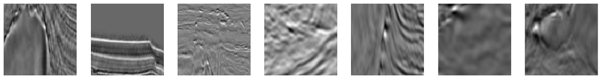

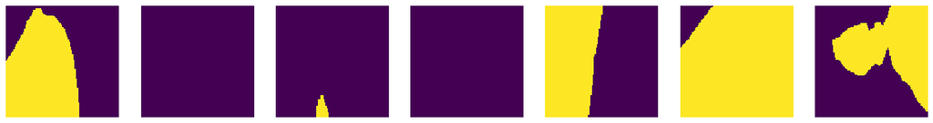

```python
import matplotlib.pyplot as plt
ids = np.random.randint(low=0,high=400,size=14)

plt.figure(figsize=(20,7))
for i in range(1,8):
    plt.subplot(1,7,i)
    plt.imshow(training_images[ids[i]])
    plt.axis('off')
plt.show()

plt.figure(figsize=(20,7))
for i in range(1,8):
    plt.subplot(1,7,i)
    plt.imshow(training_labels[ids[i],:,:,0])
    plt.axis('off')
plt.show()
```

#### The IoU metric

As a performance test an IoU test metric can be used. Mean Intersection-Over-Union is a common evaluation metric for semantic image segmentation, which first computes the IOU for each semantic class and then computes the average over classes. IOU is defined as follows: IOU = true_positive / (true_positive + false_positive + false_negative). The predictions are accumulated in a confusion matrix, weighted by weights, and mIOU is then calculated from it.

```python
def mean_iou(y_true, y_pred):
    prec = []
    for t in np.arange(0.5, 1.0, 0.05):
        y_pred_ = tf.to_int32(y_pred > t)
        score, up_opt = tf.metrics.mean_iou(y_true, y_pred_, 2)
        K.get_session().run(tf.local_variables_initializer())
        with tf.control_dependencies([up_opt]):
            score = tf.identity(score)
        prec.append(score)
    return K.mean(K.stack(prec), axis=0)
```

#### Defining the UXceptoin model.

One the metric has been defined, the UXception model backbone can be constructed. Here the Xceptoin model is used as the encoder and the decoder is made up of residual blocks. Credit goes to the following discussions and posts for this architecture:

https://www.kaggle.com/meaninglesslives/getting-0-87-on-private-lb-using-kaggle-kernel

https://www.kaggle.com/c/tgs-salt-identification-challenge/discussion/64875

https://www.kaggle.com/c/tgs-salt-identification-challenge/discussion/66568

https://www.kaggle.com/c/tgs-salt-identification-challenge/discussion/64093

After building the model, the training data was split into training and validation sets. The training set can optionally be augmented with flips, and then used as inputs for training the model. The model was only trained for 5 epochs due to GPU access limit. Of course the result can be further improved with more epochs, tuning the loss function, augmenting the images and introducing an IoU metric.

```python
# Importing the associated libraries
import tensorflow as tf
import tensorflow.keras.backend as K
from tensorflow.keras.losses import binary_crossentropy

from tensorflow.keras.preprocessing.image import load_img
from tensorflow.keras import Model
from tensorflow.keras.callbacks import  ModelCheckpoint, EarlyStopping
from tensorflow.keras.layers import Input, Conv2D, Conv2DTranspose, MaxPooling2D, concatenate, Dropout,BatchNormalization
from tensorflow.keras.layers import Conv2D, Concatenate, MaxPooling2D
from tensorflow.keras.layers import UpSampling2D, Dropout, BatchNormalization

from tensorflow.keras import initializers
from tensorflow.keras import regularizers
from tensorflow.keras import constraints

from tensorflow.python.keras.engine import get_source_inputs
from tensorflow.python.keras.engine import InputSpec
from tensorflow.keras import backend as K
from tensorflow.keras.layers import LeakyReLU
from tensorflow.keras.layers import ZeroPadding2D
from tensorflow.keras.losses import binary_crossentropy
import tensorflow.keras.callbacks as callbacks
from tensorflow.keras.callbacks import Callback
from tensorflow.keras.applications.xception import Xception
from tensorflow.keras.layers import multiply

from tensorflow.keras import optimizers

from tensorflow.python.keras.engine import Input
from tensorflow.keras.models import Model, load_model
from tensorflow.keras.layers import Conv2D, UpSampling2D, Conv2DTranspose
from tensorflow.keras.layers import Activation, SpatialDropout2D
from tensorflow.keras.layers import concatenate
from tensorflow.keras.layers import BatchNormalization
from tensorflow.keras.layers import MaxPooling2D
from tensorflow.keras.layers import Input,Dropout,BatchNormalization,Activation,Add
from tensorflow.keras.regularizers import l2
from tensorflow.keras.layers import Dense, Lambda
from tensorflow.keras.layers import concatenate, add
from tensorflow.keras.layers import GlobalAveragePooling2D, Reshape, Dense, multiply, Permute
from tensorflow.keras.optimizers import SGD
```

```python
def convolution_block(x, filters, size, strides=(1,1), padding='same', activation=True):
    x = Conv2D(filters, size, strides=strides, padding=padding)(x)
    x = BatchNormalization()(x)
    if activation == True:
        x = LeakyReLU(alpha=0.1)(x)
    return x

def residual_block(blockInput, num_filters=16):
    x = LeakyReLU(alpha=0.1)(blockInput)
    x = BatchNormalization()(x)
    blockInput = BatchNormalization()(blockInput)
    x = convolution_block(x, num_filters, (3,3) )
    x = convolution_block(x, num_filters, (3,3), activation=False)
    x = Add()([x, blockInput])
    return x
```

```python
def UXception(input_shape=(None, None, 3)):
    backbone = Xception(input_shape=input_shape,weights='imagenet',include_top=False)
    input = backbone.input
    start_neurons = 16

    conv4 = backbone.layers[121].output
    conv4 = LeakyReLU(alpha=0.1)(conv4)
    pool4 = MaxPooling2D((2, 2))(conv4)
    pool4 = Dropout(0.1)(pool4)

    # Middle
    convm = Conv2D(start_neurons * 32, (3, 3), activation=None, padding="same")(pool4)
    convm = residual_block(convm,start_neurons * 32)
    convm = residual_block(convm,start_neurons * 32)
    convm = LeakyReLU(alpha=0.1)(convm)

    # 10 -> 20
    deconv4 = Conv2DTranspose(start_neurons * 16, (3, 3), strides=(2, 2), padding="same")(convm)
    uconv4 = concatenate([deconv4, conv4])
    uconv4 = Dropout(0.1)(uconv4)

    uconv4 = Conv2D(start_neurons * 16, (3, 3), activation=None, padding="same")(uconv4)
    uconv4 = residual_block(uconv4,start_neurons * 16)
    uconv4 = residual_block(uconv4,start_neurons * 16)
    uconv4 = LeakyReLU(alpha=0.1)(uconv4)

    # 10 -> 20
    deconv3 = Conv2DTranspose(start_neurons * 8, (3, 3), strides=(2, 2), padding="same")(uconv4)
    conv3 = backbone.layers[31].output
    uconv3 = concatenate([deconv3, conv3])
    uconv3 = Dropout(0.1)(uconv3)

    uconv3 = Conv2D(start_neurons * 8, (3, 3), activation=None, padding="same")(uconv3)
    uconv3 = residual_block(uconv3,start_neurons * 8)
    uconv3 = residual_block(uconv3,start_neurons * 8)
    uconv3 = LeakyReLU(alpha=0.1)(uconv3)

    # 20 -> 40
    deconv2 = Conv2DTranspose(start_neurons * 4, (3, 3), strides=(2, 2), padding="same")(uconv3)
    conv2 = backbone.layers[21].output
    conv2 = ZeroPadding2D(((1,0),(1,0)))(conv2)
    uconv2 = concatenate([deconv2, conv2])

    uconv2 = Dropout(0.1)(uconv2)
    uconv2 = Conv2D(start_neurons * 4, (3, 3), activation=None, padding="same")(uconv2)
    uconv2 = residual_block(uconv2,start_neurons * 4)
    uconv2 = residual_block(uconv2,start_neurons * 4)
    uconv2 = LeakyReLU(alpha=0.1)(uconv2)

    # 40 -> 80
    deconv1 = Conv2DTranspose(start_neurons * 2, (3, 3), strides=(2, 2), padding="same")(uconv2)
    conv1 = backbone.layers[11].output
    conv1 = ZeroPadding2D(((3,0),(3,0)))(conv1)
    uconv1 = concatenate([deconv1, conv1])

    uconv1 = Dropout(0.1)(uconv1)
    uconv1 = Conv2D(start_neurons * 2, (3, 3), activation=None, padding="same")(uconv1)
    uconv1 = residual_block(uconv1,start_neurons * 2)
    uconv1 = residual_block(uconv1,start_neurons * 2)
    uconv1 = LeakyReLU(alpha=0.1)(uconv1)

    # 80 -> 160
    uconv0 = Conv2DTranspose(start_neurons * 1, (3, 3), strides=(2, 2), padding="same")(uconv1)
    uconv0 = Dropout(0.1)(uconv0)
    uconv0 = Conv2D(start_neurons * 1, (3, 3), activation=None, padding="same")(uconv0)
    uconv0 = residual_block(uconv0,start_neurons * 1)
    uconv0 = residual_block(uconv0,start_neurons * 1)
    uconv0 = LeakyReLU(alpha=0.1)(uconv0)

    uconv0 = Dropout(0.1/2)(uconv0)
    output_layer = Conv2D(1, (1,1), padding="same", activation="sigmoid")(uconv0)

    model = Model(input, output_layer)
#     model.name = 'u-xception'

    return model
```

```python
model = UXception(input_shape=(img_size_target,img_size_target,3))
# model = load_model('model-SALT.h5') # uncomment if resuming training
```

[output not shown]

[figure not shown]

```python
from tensorflow.keras.utils import plot_model
plot_model(model,to_file='model.png') # plot the model
plt.figure(figsize=(20,10),dpi=300)
plt.imshow(np.rot90(imread('model.png')))
plt.axis('off')
plt.tight_layout()
plt.show()
```

```python
model.compile(optimizer='adam', loss='binary_crossentropy', metrics=['accuracy'])
earlystopper = EarlyStopping(patience=5, verbose=1)
checkpointer = ModelCheckpoint('model-SALT.h5', verbose=1, save_best_only=True)
```

```python
from sklearn.model_selection import train_test_split
X_train, X_test, y_train, y_test = train_test_split(training_images,training_labels,test_size=0.2,random_state=42)
```

```python
# #augmenting the training images
# X_train = np.append(X_train, [np.fliplr(x) for x in X_train], axis=0)
# y_train = np.append(y_train, [np.fliplr(x) for x in y_train], axis=0)
```

```python
#create new tensorboard logs. call "tensorboard --logdir logs/fit" to view logs
import datetime
log_dir="logs/fit/" + datetime.datetime.now().strftime("%Y%m%d-%H%M%S")
tensorboard_callback = tf.keras.callbacks.TensorBoard(log_dir=log_dir, histogram_freq=1)

model.fit(X_train,y_train,
          validation_split=0.1,
          batch_size=8,
          epochs=5,
          callbacks=[earlystopper, checkpointer, tensorboard_callback]);
```

```
Train on 2880 samples, validate on 320 samples
WARNING:tensorflow:From C:\ProgramData\Anaconda3\envs\idp\lib\site-packages\tensorflow\python\ops\math_ops.py:3066: to_int32 (from tensorflow.python.ops.math_ops) is deprecated and will be removed in a future version.
Instructions for updating:
Use tf.cast instead.
Epoch 00001: val_loss improved from inf to 19.68875, saving model to model-SALT.h5
Epoch 00002: val_loss improved from 19.68875 to 1.71998, saving model to model-SALT.h5
Epoch 00003: val_loss did not improve from 1.71998
Epoch 00004: val_loss improved from 1.71998 to 1.50803, saving model to model-SALT.h5
Epoch 00005: val_loss improved from 1.50803 to 1.33313, saving model to model-SALT.h5
```

```python
# plotting the accuracy and loss of the model over time
# import plotly objects and generate the graphs in offline mode
from plotly import tools
import plotly.graph_objs as go
from plotly.offline import download_plotlyjs, init_notebook_mode, plot, iplot
init_notebook_mode(connected=True)

epochs = np.linspace(0,len(model.history.history['loss']),len(model.history.history['loss'])+1)
loss = model.history.history['loss']
val_loss = model.history.history['val_loss']
mean_iou = model.history.history['acc']
val_mean_iou = model.history.history['val_acc']

trace1 = go.Scatter(x=epochs,y=loss,name="loss")
trace2 = go.Scatter(x=epochs,y=val_loss,name="validation loss")
trace3 = go.Scatter(x=epochs,y=mean_iou,name="accuracy")
trace4 = go.Scatter(x=epochs,y=val_mean_iou,name="validation accuracy")

fig = tools.make_subplots(rows=1, cols=2)
fig.append_trace(trace1, 1, 1)
fig.append_trace(trace2, 1, 1)
fig.append_trace(trace3, 1, 2)
fig.append_trace(trace4, 1, 2)
fig['layout'].update(height=400,
                     width=900,
                     title='Comparison of training and validation progress with increasing epochs')
fig['layout']['xaxis1'].update(title='epoch')
fig['layout']['xaxis2'].update(title='epoch')
fig['layout']['yaxis1'].update(title='loss')
fig['layout']['yaxis2'].update(title='accuracy')
iplot(fig)
```

[output not shown]

```python
model = load_model('model-SALT.h5')
```

Checking the test set predictions after training the model.

```python
pred_test = model.predict(X_test)
```

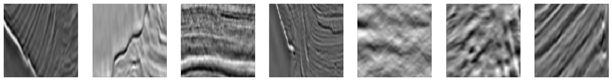

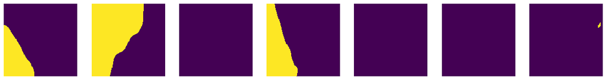

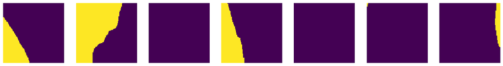

```python
ids = np.random.randint(low=0,high=400,size=14)

plt.figure(figsize=(20,7))
for i in range(1,8):
    plt.subplot(1,7,i)
    plt.imshow(X_test[ids[i]])
    plt.axis('off')
plt.show()

plt.figure(figsize=(20,7))
for i in range(1,8):
    plt.subplot(1,7,i)
    plt.imshow(pred_test[ids[i],:,:,0]>0.7)
    plt.axis('off')
plt.show()

plt.figure(figsize=(20,7))
for i in range(1,8):
    plt.subplot(1,7,i)
    plt.imshow(y_test[ids[i],:,:,0])
    plt.axis('off')
plt.show()
```

#### Scoring the model and closing remarks

Overall, from the initial images shown above give a representation that the model has trained well despite only training for 5 epochs.

Things to consider to improve the model:

1. Add a IoU metric
2. Perform a similarity test between the predictions and the manually labelled data to determine the best threshold
3. Run the model for longer
4. Define a more optimised loss function for faster convergence
5. Add augmentations.